# **Problem Statement**: Used Car Price Analysis

#### Understand how various factors like brand, fuel type, transmission, year of manufacture, kilometers driven, and location affect the price of used cars.

#### Identify pricing trends and patterns across cities and car categories.

# **Data Scrapping** : Used Cars

```python
from selenium import webdriver
from selenium.webdriver.edge.service import Service as EdgeService
from selenium.webdriver.edge.options import Options as EdgeOptions           # importing Libraries
from webdriver_manager.microsoft import EdgeChromiumDriverManager
from bs4 import BeautifulSoup
import pandas as pd
import numpy as np
import time


options = EdgeOptions()
options.add_argument("--start-maximized")                               # setup browser
service = EdgeService(EdgeChromiumDriverManager().install())


locations = ["bangalore", "delhi", "mumbai", "hyderabad", "chennai","lucknow","kolkata","pune","jaipur","gurgaon","noida","delhi-ncr"]  # Add more cities here

all_cars = []

for city in locations:
    print(f"Scraping city: {city}...")
    url = f"https://www.spinny.com/used-cars-in-{city}/s/"               #scrapping website

    driver = webdriver.Edge(service=service, options=options)             #web driver
    driver.get(url)
    time.sleep(5)

    last_height = driver.execute_script("return document.body.scrollHeight")
    for _ in range(30):                                                               # for loop for iterate pages
        driver.execute_script("window.scrollTo(0, document.body.scrollHeight);")
        time.sleep(2)
        new_height = driver.execute_script("return document.body.scrollHeight")
        if new_height == last_height:
            break
        last_height = new_height

    soup = BeautifulSoup(driver.page_source, "html.parser")                             # using Beautifulsoup
    driver.quit()

    Car_Name, Price, KMS, Fuel, Transmission, Location,Emi = [], [], [], [], [], [], []

    cars = soup.find_all("div", class_="CarListingCardDetail__productDetailContainer")
    for car in cars:
        name = car.find("h3", class_="ListingBrandModelDetail__makeModelInfo ListingBrandModelDetail__medium")
        Car_Name.append(name.text.strip() if name else np.nan)

        price = car.find("li", class_="ListingPricingDetail__price ListingPricingDetail__medium")
        Price.append(price.text.strip() if price else np.nan)

        loc = car.find("span", class_="HubDetails__hubAddress")
        Location.append(loc.text.strip() if loc else city.title())  # Default to city if not found

        emi = car.find("li", class_="ListingPricingDetail__emi ListingPricingDetail__medium")
        Emi.append(emi.text.strip() if emi else np.nan)

    sections = soup.find_all("ul", class_="CarListingCardDetail__more")
    for sec in sections:
        li_tags = sec.find_all("li")
        if len(li_tags) >= 3:
            KMS.append(li_tags[0].text.strip())
            Fuel.append(li_tags[1].text.strip())
            Transmission.append(li_tags[2].text.strip())
        else:
            KMS.append(np.nan)
            Fuel.append(np.nan)
            Transmission.append(np.nan)

    min_len = min(len(Car_Name), len(Price), len(KMS), len(Fuel), len(Transmission), len(Location),len(Emi))
    df = pd.DataFrame({
        "City": [city.title()] * min_len,
        "Car_Name": Car_Name[:min_len],
        "Price": Price[:min_len],
        "KMS": KMS[:min_len],
        "Fuel": Fuel[:min_len],
        "Transmission": Transmission[:min_len],
        "Location": Location[:min_len],
        "Emi":Emi[:min_len]
    })

    all_cars.append(df)

# Combine all cities into one DataFrame
final_df = pd.concat(all_cars, ignore_index=True)

final_df
```

```
Scraping city: bangalore...
Scraping city: delhi...
Scraping city: mumbai...
Scraping city: hyderabad...
Scraping city: chennai...
Scraping city: lucknow...
Scraping city: kolkata...
Scraping city: pune...
Scraping city: jaipur...
Scraping city: gurgaon...
Scraping city: noida...
Scraping city: delhi-ncr...
```

|  | City | Car_Name | Price | KMS | Fuel | Transmission | Location | Emi |
| --- | --- | --- | --- | --- | --- | --- | --- | --- |
| 0 | Bangalore | 2017 Maruti Vitara BrezzaZDi | 6.91 Lakh | 75K km | diesel | manual | Spinny Car Hub, Bangalore Vega Mall | EMI ₹11,767/m* |
| 1 | Bangalore | 2018 Maruti Vitara BrezzaZDi+ Dual Tone | 8.21 Lakh | 90K km | diesel | manual | Spinny Car Hub, Nexus Shanti Niketan Mall - Wh... | EMI ₹13,981/m* |
| 2 | Bangalore | 2018 Mercedes E-ClassE220d Avantgarde | 37.50 Lakh | 36.5K km | diesel | automatic | Spinny Park, Yelahanka, Bangalore | EMI ₹64,496/m* |
| 3 | Bangalore | 2016 Volkswagen PoloGT TSI | 5.96 Lakh | 114K km | petrol | automatic | Spinny Car Hub, Nexus Shanti Niketan Mall - Wh... | EMI ₹9,515/m* |
| 4 | Bangalore | 2015 Hyundai Elite i20Asta 1.2 | 5.68 Lakh | 59K km | petrol | manual | Spinny Car Hub, Mantri Mall, Bangalore | EMI ₹10,338/m* |
| ... | ... | ... | ... | ... | ... | ... | ... | ... |
| 6706 | Delhi-Ncr | 2017 Hyundai Grand i10Sportz 1.2 Kappa VTVT | 4.19 Lakh | 57K km | petrol | manual | Delhi-Ncr | EMI ₹7,135/m* |
| 6707 | Delhi-Ncr | 2022 Maruti Wagon R 1.0LXI CNG | 5.60 Lakh | 7K km | petrol+cng | manual | Spinny Car Hub, GNB Mall Ghaziabad | EMI ₹9,536/m* |
| 6708 | Delhi-Ncr | 2022 Tata TigorRevotron XZ+ CNG | 6.68 Lakh | 21.5K km | petrol+cng | manual | Spinny Car Hub, Trillium Avenue, Gurgaon | EMI ₹11,375/m* |
| 6709 | Delhi-Ncr | 2022 Maruti Alto 800LXi (O) | 3.66 Lakh | 11K km | petrol | manual | Spinny Car Hub, GNB Mall Ghaziabad | EMI ₹6,541/m* |
| 6710 | Delhi-Ncr | 2023 Hyundai AuraSX 1.2 CNG | 7.46 Lakh | 35.5K km | petrol+cng | manual | Delhi-Ncr | EMI ₹12,703/m* |

6711 rows × 8 columns

### save dataframe

```python
final_df.to_csv("spinny_project.csv",index=False)
```

## importing neccesary libraries

```python
import pandas as pd
import numpy as np
import time
import warnings
warnings.filterwarnings('ignore')
```

### load the dataframe

```python
df=pd.read_csv("spinny_project.csv")
df
```

|  | City | Car_Name | Price | KMS | Fuel | Transmission | Location | Emi |
| --- | --- | --- | --- | --- | --- | --- | --- | --- |
| 0 | Bangalore | 2017 Maruti Vitara BrezzaZDi | 6.91 Lakh | 75K km | diesel | manual | Spinny Car Hub, Bangalore Vega Mall | EMI ₹11,767/m* |
| 1 | Bangalore | 2018 Maruti Vitara BrezzaZDi+ Dual Tone | 8.21 Lakh | 90K km | diesel | manual | Spinny Car Hub, Nexus Shanti Niketan Mall - Wh... | EMI ₹13,981/m* |
| 2 | Bangalore | 2018 Mercedes E-ClassE220d Avantgarde | 37.50 Lakh | 36.5K km | diesel | automatic | Spinny Park, Yelahanka, Bangalore | EMI ₹64,496/m* |
| 3 | Bangalore | 2016 Volkswagen PoloGT TSI | 5.96 Lakh | 114K km | petrol | automatic | Spinny Car Hub, Nexus Shanti Niketan Mall - Wh... | EMI ₹9,515/m* |
| 4 | Bangalore | 2015 Hyundai Elite i20Asta 1.2 | 5.68 Lakh | 59K km | petrol | manual | Spinny Car Hub, Mantri Mall, Bangalore | EMI ₹10,338/m* |
| ... | ... | ... | ... | ... | ... | ... | ... | ... |
| 6706 | Delhi-Ncr | 2017 Hyundai Grand i10Sportz 1.2 Kappa VTVT | 4.19 Lakh | 57K km | petrol | manual | Delhi-Ncr | EMI ₹7,135/m* |
| 6707 | Delhi-Ncr | 2022 Maruti Wagon R 1.0LXI CNG | 5.60 Lakh | 7K km | petrol+cng | manual | Spinny Car Hub, GNB Mall Ghaziabad | EMI ₹9,536/m* |
| 6708 | Delhi-Ncr | 2022 Tata TigorRevotron XZ+ CNG | 6.68 Lakh | 21.5K km | petrol+cng | manual | Spinny Car Hub, Trillium Avenue, Gurgaon | EMI ₹11,375/m* |
| 6709 | Delhi-Ncr | 2022 Maruti Alto 800LXi (O) | 3.66 Lakh | 11K km | petrol | manual | Spinny Car Hub, GNB Mall Ghaziabad | EMI ₹6,541/m* |
| 6710 | Delhi-Ncr | 2023 Hyundai AuraSX 1.2 CNG | 7.46 Lakh | 35.5K km | petrol+cng | manual | Delhi-Ncr | EMI ₹12,703/m* |

6711 rows × 8 columns

## Understanding the dataframe

```python
df.shape
```

```
(6711, 8)
```

-here we have a 6711 rows, 8 columns

```python
df.head()
```

|  | City | Car_Name | Price | KMS | Fuel | Transmission | Location | Emi |
| --- | --- | --- | --- | --- | --- | --- | --- | --- |
| 0 | Bangalore | 2017 Maruti Vitara BrezzaZDi | 6.91 Lakh | 75K km | diesel | manual | Spinny Car Hub, Bangalore Vega Mall | EMI ₹11,767/m* |
| 1 | Bangalore | 2018 Maruti Vitara BrezzaZDi+ Dual Tone | 8.21 Lakh | 90K km | diesel | manual | Spinny Car Hub, Nexus Shanti Niketan Mall - Wh... | EMI ₹13,981/m* |
| 2 | Bangalore | 2018 Mercedes E-ClassE220d Avantgarde | 37.50 Lakh | 36.5K km | diesel | automatic | Spinny Park, Yelahanka, Bangalore | EMI ₹64,496/m* |
| 3 | Bangalore | 2016 Volkswagen PoloGT TSI | 5.96 Lakh | 114K km | petrol | automatic | Spinny Car Hub, Nexus Shanti Niketan Mall - Wh... | EMI ₹9,515/m* |
| 4 | Bangalore | 2015 Hyundai Elite i20Asta 1.2 | 5.68 Lakh | 59K km | petrol | manual | Spinny Car Hub, Mantri Mall, Bangalore | EMI ₹10,338/m* |

```python
df.tail()
```

|  | City | Car_Name | Price | KMS | Fuel | Transmission | Location | Emi |
| --- | --- | --- | --- | --- | --- | --- | --- | --- |
| 6706 | Delhi-Ncr | 2017 Hyundai Grand i10Sportz 1.2 Kappa VTVT | 4.19 Lakh | 57K km | petrol | manual | Delhi-Ncr | EMI ₹7,135/m* |
| 6707 | Delhi-Ncr | 2022 Maruti Wagon R 1.0LXI CNG | 5.60 Lakh | 7K km | petrol+cng | manual | Spinny Car Hub, GNB Mall Ghaziabad | EMI ₹9,536/m* |
| 6708 | Delhi-Ncr | 2022 Tata TigorRevotron XZ+ CNG | 6.68 Lakh | 21.5K km | petrol+cng | manual | Spinny Car Hub, Trillium Avenue, Gurgaon | EMI ₹11,375/m* |
| 6709 | Delhi-Ncr | 2022 Maruti Alto 800LXi (O) | 3.66 Lakh | 11K km | petrol | manual | Spinny Car Hub, GNB Mall Ghaziabad | EMI ₹6,541/m* |
| 6710 | Delhi-Ncr | 2023 Hyundai AuraSX 1.2 CNG | 7.46 Lakh | 35.5K km | petrol+cng | manual | Delhi-Ncr | EMI ₹12,703/m* |

```python
df.sample(5)
```

|  | City | Car_Name | Price | KMS | Fuel | Transmission | Location | Emi |
| --- | --- | --- | --- | --- | --- | --- | --- | --- |
| 5959 | Delhi-Ncr | 2021 Honda Amaze1.2 VX MT Petrol | 6.67 Lakh | 45K km | petrol | manual | Spinny Car Hub, Universal Trade Tower, Sohna R... | EMI ₹11,358/m* |
| 2794 | Hyderabad | 2024 Kia SeltosGTX+ 1.5l CRDI VGT Diesel AT | 18.19 Lakh | 29.5K km | diesel | automatic | Hyderabad | EMI ₹31,283/m* |
| 3944 | Pune | 2018 Maruti CelerioZXi AMT | 4.77 Lakh | 40.5K km | petrol | automatic | Spinny Car Hub, Seasons Mall, Pune | EMI ₹8,123/m* |
| 991 | Delhi | 2019 Hyundai VenueSX Plus 1.0 Turbo DCT | 8.49 Lakh | 33K km | petrol | automatic | Spinny Car Hub, Indirapuram Habitat Centre, Gh... | EMI ₹14,457/m* |
| 3779 | Kolkata | 2021 Maruti S-PressoVXI Plus | 4.14 Lakh | 18.5K km | petrol | manual | Spinny Car Hub, Acropolis Mall, Kolkata | EMI ₹7,050/m* |

```python
df.columns
```

```
Index(['City', 'Car_Name', 'Price', 'KMS', 'Fuel', 'Transmission', 'Location',
       'Emi'],
      dtype='object')
```

```python
df.dtypes
```

```
City            object
Car_Name        object
Price           object
KMS             object
Fuel            object
Transmission    object
Location        object
Emi             object
dtype: object
```

```python
df.index
```

```
RangeIndex(start=0, stop=6711, step=1)
```

```python
df.info()
```

```
<class 'pandas.core.frame.DataFrame'>
RangeIndex: 6711 entries, 0 to 6710
Data columns (total 8 columns):
 #   Column        Non-Null Count  Dtype
---  ------        --------------  -----
 0   City          6711 non-null   object
 1   Car_Name      6711 non-null   object
 2   Price         6711 non-null   object
 3   KMS           6711 non-null   object
 4   Fuel          6711 non-null   object
 5   Transmission  6711 non-null   object
 6   Location      6711 non-null   object
 7   Emi           6669 non-null   object
dtypes: object(8)
memory usage: 419.6+ KB
```

```python
df.describe()
```

|  | City | Car_Name | Price | KMS | Fuel | Transmission | Location | Emi |
| --- | --- | --- | --- | --- | --- | --- | --- | --- |
| count | 6711 | 6711 | 6711 | 6711 | 6711 | 6711 | 6711 | 6669 |
| unique | 12 | 2523 | 1236 | 282 | 6 | 2 | 50 | 2290 |
| top | Delhi-Ncr | 2022 Tata TigorRevotron XZ+ CNG | 7.97 Lakh | 41.5K km | petrol | manual | Spinny Car Hub, Gaur City, Noida | EMI ₹13,572/m* |
| freq | 1361 | 26 | 29 | 67 | 5489 | 4588 | 452 | 28 |

## Data Cleaning

#### handling duplicates

```python
df.duplicated().sum()          # this function used for checking a duplicates
```

```
20
```

```python
df=df.drop_duplicates()
df
```

|  | City | Car_Name | Price | KMS | Fuel | Transmission | Location | Emi |
| --- | --- | --- | --- | --- | --- | --- | --- | --- |
| 0 | Bangalore | 2017 Maruti Vitara BrezzaZDi | 6.91 Lakh | 75K km | diesel | manual | Spinny Car Hub, Bangalore Vega Mall | EMI ₹11,767/m* |
| 1 | Bangalore | 2018 Maruti Vitara BrezzaZDi+ Dual Tone | 8.21 Lakh | 90K km | diesel | manual | Spinny Car Hub, Nexus Shanti Niketan Mall - Wh... | EMI ₹13,981/m* |
| 2 | Bangalore | 2018 Mercedes E-ClassE220d Avantgarde | 37.50 Lakh | 36.5K km | diesel | automatic | Spinny Park, Yelahanka, Bangalore | EMI ₹64,496/m* |
| 3 | Bangalore | 2016 Volkswagen PoloGT TSI | 5.96 Lakh | 114K km | petrol | automatic | Spinny Car Hub, Nexus Shanti Niketan Mall - Wh... | EMI ₹9,515/m* |
| 4 | Bangalore | 2015 Hyundai Elite i20Asta 1.2 | 5.68 Lakh | 59K km | petrol | manual | Spinny Car Hub, Mantri Mall, Bangalore | EMI ₹10,338/m* |
| ... | ... | ... | ... | ... | ... | ... | ... | ... |
| 6706 | Delhi-Ncr | 2017 Hyundai Grand i10Sportz 1.2 Kappa VTVT | 4.19 Lakh | 57K km | petrol | manual | Delhi-Ncr | EMI ₹7,135/m* |
| 6707 | Delhi-Ncr | 2022 Maruti Wagon R 1.0LXI CNG | 5.60 Lakh | 7K km | petrol+cng | manual | Spinny Car Hub, GNB Mall Ghaziabad | EMI ₹9,536/m* |
| 6708 | Delhi-Ncr | 2022 Tata TigorRevotron XZ+ CNG | 6.68 Lakh | 21.5K km | petrol+cng | manual | Spinny Car Hub, Trillium Avenue, Gurgaon | EMI ₹11,375/m* |
| 6709 | Delhi-Ncr | 2022 Maruti Alto 800LXi (O) | 3.66 Lakh | 11K km | petrol | manual | Spinny Car Hub, GNB Mall Ghaziabad | EMI ₹6,541/m* |
| 6710 | Delhi-Ncr | 2023 Hyundai AuraSX 1.2 CNG | 7.46 Lakh | 35.5K km | petrol+cng | manual | Delhi-Ncr | EMI ₹12,703/m* |

6691 rows × 8 columns

#### missing values

```python
df.isnull().sum()
```

```
City             0
Car_Name         0
Price            0
KMS              0
Fuel             0
Transmission     0
Location         0
Emi             41
dtype: int64
```

```python
df=df.dropna()                                #dropping null values
```

```python
df
```

|  | City | Car_Name | Price | KMS | Fuel | Transmission | Location | Emi |
| --- | --- | --- | --- | --- | --- | --- | --- | --- |
| 0 | Bangalore | 2017 Maruti Vitara BrezzaZDi | 6.91 Lakh | 75K km | diesel | manual | Spinny Car Hub, Bangalore Vega Mall | EMI ₹11,767/m* |
| 1 | Bangalore | 2018 Maruti Vitara BrezzaZDi+ Dual Tone | 8.21 Lakh | 90K km | diesel | manual | Spinny Car Hub, Nexus Shanti Niketan Mall - Wh... | EMI ₹13,981/m* |
| 2 | Bangalore | 2018 Mercedes E-ClassE220d Avantgarde | 37.50 Lakh | 36.5K km | diesel | automatic | Spinny Park, Yelahanka, Bangalore | EMI ₹64,496/m* |
| 3 | Bangalore | 2016 Volkswagen PoloGT TSI | 5.96 Lakh | 114K km | petrol | automatic | Spinny Car Hub, Nexus Shanti Niketan Mall - Wh... | EMI ₹9,515/m* |
| 4 | Bangalore | 2015 Hyundai Elite i20Asta 1.2 | 5.68 Lakh | 59K km | petrol | manual | Spinny Car Hub, Mantri Mall, Bangalore | EMI ₹10,338/m* |
| ... | ... | ... | ... | ... | ... | ... | ... | ... |
| 6706 | Delhi-Ncr | 2017 Hyundai Grand i10Sportz 1.2 Kappa VTVT | 4.19 Lakh | 57K km | petrol | manual | Delhi-Ncr | EMI ₹7,135/m* |
| 6707 | Delhi-Ncr | 2022 Maruti Wagon R 1.0LXI CNG | 5.60 Lakh | 7K km | petrol+cng | manual | Spinny Car Hub, GNB Mall Ghaziabad | EMI ₹9,536/m* |
| 6708 | Delhi-Ncr | 2022 Tata TigorRevotron XZ+ CNG | 6.68 Lakh | 21.5K km | petrol+cng | manual | Spinny Car Hub, Trillium Avenue, Gurgaon | EMI ₹11,375/m* |
| 6709 | Delhi-Ncr | 2022 Maruti Alto 800LXi (O) | 3.66 Lakh | 11K km | petrol | manual | Spinny Car Hub, GNB Mall Ghaziabad | EMI ₹6,541/m* |
| 6710 | Delhi-Ncr | 2023 Hyundai AuraSX 1.2 CNG | 7.46 Lakh | 35.5K km | petrol+cng | manual | Delhi-Ncr | EMI ₹12,703/m* |

6650 rows × 8 columns

```python
df.info()
```

```
<class 'pandas.core.frame.DataFrame'>
Index: 6650 entries, 0 to 6710
Data columns (total 8 columns):
 #   Column        Non-Null Count  Dtype
---  ------        --------------  -----
 0   City          6650 non-null   object
 1   Car_Name      6650 non-null   object
 2   Price         6650 non-null   object
 3   KMS           6650 non-null   object
 4   Fuel          6650 non-null   object
 5   Transmission  6650 non-null   object
 6   Location      6650 non-null   object
 7   Emi           6650 non-null   object
dtypes: object(8)
memory usage: 467.6+ KB
```

### using regular expression (REGEX) to do some manupluations and cleaning the dataset

extracting year from car-name column and adding to dataset that year column

```python
import warnings
warnings.simplefilter(action='ignore', category=FutureWarning)
```

```python
df['Year'] = df['Car_Name'].str.extract(r'^(\d{4})')
df
```

|  | City | Car_Name | Price | KMS | Fuel | Transmission | Location | Emi | Year |
| --- | --- | --- | --- | --- | --- | --- | --- | --- | --- |
| 0 | Bangalore | 2017 Maruti Vitara BrezzaZDi | 6.91 Lakh | 75K km | diesel | manual | Spinny Car Hub, Bangalore Vega Mall | EMI ₹11,767/m* | 2017 |
| 1 | Bangalore | 2018 Maruti Vitara BrezzaZDi+ Dual Tone | 8.21 Lakh | 90K km | diesel | manual | Spinny Car Hub, Nexus Shanti Niketan Mall - Wh... | EMI ₹13,981/m* | 2018 |
| 2 | Bangalore | 2018 Mercedes E-ClassE220d Avantgarde | 37.50 Lakh | 36.5K km | diesel | automatic | Spinny Park, Yelahanka, Bangalore | EMI ₹64,496/m* | 2018 |
| 3 | Bangalore | 2016 Volkswagen PoloGT TSI | 5.96 Lakh | 114K km | petrol | automatic | Spinny Car Hub, Nexus Shanti Niketan Mall - Wh... | EMI ₹9,515/m* | 2016 |
| 4 | Bangalore | 2015 Hyundai Elite i20Asta 1.2 | 5.68 Lakh | 59K km | petrol | manual | Spinny Car Hub, Mantri Mall, Bangalore | EMI ₹10,338/m* | 2015 |
| ... | ... | ... | ... | ... | ... | ... | ... | ... | ... |
| 6706 | Delhi-Ncr | 2017 Hyundai Grand i10Sportz 1.2 Kappa VTVT | 4.19 Lakh | 57K km | petrol | manual | Delhi-Ncr | EMI ₹7,135/m* | 2017 |
| 6707 | Delhi-Ncr | 2022 Maruti Wagon R 1.0LXI CNG | 5.60 Lakh | 7K km | petrol+cng | manual | Spinny Car Hub, GNB Mall Ghaziabad | EMI ₹9,536/m* | 2022 |
| 6708 | Delhi-Ncr | 2022 Tata TigorRevotron XZ+ CNG | 6.68 Lakh | 21.5K km | petrol+cng | manual | Spinny Car Hub, Trillium Avenue, Gurgaon | EMI ₹11,375/m* | 2022 |
| 6709 | Delhi-Ncr | 2022 Maruti Alto 800LXi (O) | 3.66 Lakh | 11K km | petrol | manual | Spinny Car Hub, GNB Mall Ghaziabad | EMI ₹6,541/m* | 2022 |
| 6710 | Delhi-Ncr | 2023 Hyundai AuraSX 1.2 CNG | 7.46 Lakh | 35.5K km | petrol+cng | manual | Delhi-Ncr | EMI ₹12,703/m* | 2023 |

6650 rows × 9 columns

###### using regex seperating a brand name and model

```python
df['Car'] = df['Car_Name'].str.replace(r'^\d{4}\s+', '', regex=True)
df
```

|  | City | Car_Name | Price | KMS | Fuel | Transmission | Location | Emi | Year | Car |
| --- | --- | --- | --- | --- | --- | --- | --- | --- | --- | --- |
| 0 | Bangalore | 2017 Maruti Vitara BrezzaZDi | 6.91 Lakh | 75K km | diesel | manual | Spinny Car Hub, Bangalore Vega Mall | EMI ₹11,767/m* | 2017 | Maruti Vitara BrezzaZDi |
| 1 | Bangalore | 2018 Maruti Vitara BrezzaZDi+ Dual Tone | 8.21 Lakh | 90K km | diesel | manual | Spinny Car Hub, Nexus Shanti Niketan Mall - Wh... | EMI ₹13,981/m* | 2018 | Maruti Vitara BrezzaZDi+ Dual Tone |
| 2 | Bangalore | 2018 Mercedes E-ClassE220d Avantgarde | 37.50 Lakh | 36.5K km | diesel | automatic | Spinny Park, Yelahanka, Bangalore | EMI ₹64,496/m* | 2018 | Mercedes E-ClassE220d Avantgarde |
| 3 | Bangalore | 2016 Volkswagen PoloGT TSI | 5.96 Lakh | 114K km | petrol | automatic | Spinny Car Hub, Nexus Shanti Niketan Mall - Wh... | EMI ₹9,515/m* | 2016 | Volkswagen PoloGT TSI |
| 4 | Bangalore | 2015 Hyundai Elite i20Asta 1.2 | 5.68 Lakh | 59K km | petrol | manual | Spinny Car Hub, Mantri Mall, Bangalore | EMI ₹10,338/m* | 2015 | Hyundai Elite i20Asta 1.2 |
| ... | ... | ... | ... | ... | ... | ... | ... | ... | ... | ... |
| 6706 | Delhi-Ncr | 2017 Hyundai Grand i10Sportz 1.2 Kappa VTVT | 4.19 Lakh | 57K km | petrol | manual | Delhi-Ncr | EMI ₹7,135/m* | 2017 | Hyundai Grand i10Sportz 1.2 Kappa VTVT |
| 6707 | Delhi-Ncr | 2022 Maruti Wagon R 1.0LXI CNG | 5.60 Lakh | 7K km | petrol+cng | manual | Spinny Car Hub, GNB Mall Ghaziabad | EMI ₹9,536/m* | 2022 | Maruti Wagon R 1.0LXI CNG |
| 6708 | Delhi-Ncr | 2022 Tata TigorRevotron XZ+ CNG | 6.68 Lakh | 21.5K km | petrol+cng | manual | Spinny Car Hub, Trillium Avenue, Gurgaon | EMI ₹11,375/m* | 2022 | Tata TigorRevotron XZ+ CNG |
| 6709 | Delhi-Ncr | 2022 Maruti Alto 800LXi (O) | 3.66 Lakh | 11K km | petrol | manual | Spinny Car Hub, GNB Mall Ghaziabad | EMI ₹6,541/m* | 2022 | Maruti Alto 800LXi (O) |
| 6710 | Delhi-Ncr | 2023 Hyundai AuraSX 1.2 CNG | 7.46 Lakh | 35.5K km | petrol+cng | manual | Delhi-Ncr | EMI ₹12,703/m* | 2023 | Hyundai AuraSX 1.2 CNG |

6650 rows × 10 columns

```python
df.drop(columns=['Car_Name'] )      # droping column
```

|  | City | Price | KMS | Fuel | Transmission | Location | Emi | Year | Car |
| --- | --- | --- | --- | --- | --- | --- | --- | --- | --- |
| 0 | Bangalore | 6.91 Lakh | 75K km | diesel | manual | Spinny Car Hub, Bangalore Vega Mall | EMI ₹11,767/m* | 2017 | Maruti Vitara BrezzaZDi |
| 1 | Bangalore | 8.21 Lakh | 90K km | diesel | manual | Spinny Car Hub, Nexus Shanti Niketan Mall - Wh... | EMI ₹13,981/m* | 2018 | Maruti Vitara BrezzaZDi+ Dual Tone |
| 2 | Bangalore | 37.50 Lakh | 36.5K km | diesel | automatic | Spinny Park, Yelahanka, Bangalore | EMI ₹64,496/m* | 2018 | Mercedes E-ClassE220d Avantgarde |
| 3 | Bangalore | 5.96 Lakh | 114K km | petrol | automatic | Spinny Car Hub, Nexus Shanti Niketan Mall - Wh... | EMI ₹9,515/m* | 2016 | Volkswagen PoloGT TSI |
| 4 | Bangalore | 5.68 Lakh | 59K km | petrol | manual | Spinny Car Hub, Mantri Mall, Bangalore | EMI ₹10,338/m* | 2015 | Hyundai Elite i20Asta 1.2 |
| ... | ... | ... | ... | ... | ... | ... | ... | ... | ... |
| 6706 | Delhi-Ncr | 4.19 Lakh | 57K km | petrol | manual | Delhi-Ncr | EMI ₹7,135/m* | 2017 | Hyundai Grand i10Sportz 1.2 Kappa VTVT |
| 6707 | Delhi-Ncr | 5.60 Lakh | 7K km | petrol+cng | manual | Spinny Car Hub, GNB Mall Ghaziabad | EMI ₹9,536/m* | 2022 | Maruti Wagon R 1.0LXI CNG |
| 6708 | Delhi-Ncr | 6.68 Lakh | 21.5K km | petrol+cng | manual | Spinny Car Hub, Trillium Avenue, Gurgaon | EMI ₹11,375/m* | 2022 | Tata TigorRevotron XZ+ CNG |
| 6709 | Delhi-Ncr | 3.66 Lakh | 11K km | petrol | manual | Spinny Car Hub, GNB Mall Ghaziabad | EMI ₹6,541/m* | 2022 | Maruti Alto 800LXi (O) |
| 6710 | Delhi-Ncr | 7.46 Lakh | 35.5K km | petrol+cng | manual | Delhi-Ncr | EMI ₹12,703/m* | 2023 | Hyundai AuraSX 1.2 CNG |

6650 rows × 9 columns

###### here reasigning a columns

```python
df = df[['Car', 'Year','City', 'KMS', 'Fuel', 'Transmission', 'Price','Emi']]                 # arranging columns sequntially
df
```

|  | Car | Year | City | KMS | Fuel | Transmission | Price | Emi |
| --- | --- | --- | --- | --- | --- | --- | --- | --- |
| 0 | Maruti Vitara BrezzaZDi | 2017 | Bangalore | 75K km | diesel | manual | 6.91 Lakh | EMI ₹11,767/m* |
| 1 | Maruti Vitara BrezzaZDi+ Dual Tone | 2018 | Bangalore | 90K km | diesel | manual | 8.21 Lakh | EMI ₹13,981/m* |
| 2 | Mercedes E-ClassE220d Avantgarde | 2018 | Bangalore | 36.5K km | diesel | automatic | 37.50 Lakh | EMI ₹64,496/m* |
| 3 | Volkswagen PoloGT TSI | 2016 | Bangalore | 114K km | petrol | automatic | 5.96 Lakh | EMI ₹9,515/m* |
| 4 | Hyundai Elite i20Asta 1.2 | 2015 | Bangalore | 59K km | petrol | manual | 5.68 Lakh | EMI ₹10,338/m* |
| ... | ... | ... | ... | ... | ... | ... | ... | ... |
| 6706 | Hyundai Grand i10Sportz 1.2 Kappa VTVT | 2017 | Delhi-Ncr | 57K km | petrol | manual | 4.19 Lakh | EMI ₹7,135/m* |
| 6707 | Maruti Wagon R 1.0LXI CNG | 2022 | Delhi-Ncr | 7K km | petrol+cng | manual | 5.60 Lakh | EMI ₹9,536/m* |
| 6708 | Tata TigorRevotron XZ+ CNG | 2022 | Delhi-Ncr | 21.5K km | petrol+cng | manual | 6.68 Lakh | EMI ₹11,375/m* |
| 6709 | Maruti Alto 800LXi (O) | 2022 | Delhi-Ncr | 11K km | petrol | manual | 3.66 Lakh | EMI ₹6,541/m* |
| 6710 | Hyundai AuraSX 1.2 CNG | 2023 | Delhi-Ncr | 35.5K km | petrol+cng | manual | 7.46 Lakh | EMI ₹12,703/m* |

6650 rows × 8 columns

##### here extracting brand name from car column

```python
df['Brand'] = df['Car'].str.extract(r'^(\w+)')
df
```

|  | Car | Year | City | KMS | Fuel | Transmission | Price | Emi | Brand |
| --- | --- | --- | --- | --- | --- | --- | --- | --- | --- |
| 0 | Maruti Vitara BrezzaZDi | 2017 | Bangalore | 75K km | diesel | manual | 6.91 Lakh | EMI ₹11,767/m* | Maruti |
| 1 | Maruti Vitara BrezzaZDi+ Dual Tone | 2018 | Bangalore | 90K km | diesel | manual | 8.21 Lakh | EMI ₹13,981/m* | Maruti |
| 2 | Mercedes E-ClassE220d Avantgarde | 2018 | Bangalore | 36.5K km | diesel | automatic | 37.50 Lakh | EMI ₹64,496/m* | Mercedes |
| 3 | Volkswagen PoloGT TSI | 2016 | Bangalore | 114K km | petrol | automatic | 5.96 Lakh | EMI ₹9,515/m* | Volkswagen |
| 4 | Hyundai Elite i20Asta 1.2 | 2015 | Bangalore | 59K km | petrol | manual | 5.68 Lakh | EMI ₹10,338/m* | Hyundai |
| ... | ... | ... | ... | ... | ... | ... | ... | ... | ... |
| 6706 | Hyundai Grand i10Sportz 1.2 Kappa VTVT | 2017 | Delhi-Ncr | 57K km | petrol | manual | 4.19 Lakh | EMI ₹7,135/m* | Hyundai |
| 6707 | Maruti Wagon R 1.0LXI CNG | 2022 | Delhi-Ncr | 7K km | petrol+cng | manual | 5.60 Lakh | EMI ₹9,536/m* | Maruti |
| 6708 | Tata TigorRevotron XZ+ CNG | 2022 | Delhi-Ncr | 21.5K km | petrol+cng | manual | 6.68 Lakh | EMI ₹11,375/m* | Tata |
| 6709 | Maruti Alto 800LXi (O) | 2022 | Delhi-Ncr | 11K km | petrol | manual | 3.66 Lakh | EMI ₹6,541/m* | Maruti |
| 6710 | Hyundai AuraSX 1.2 CNG | 2023 | Delhi-Ncr | 35.5K km | petrol+cng | manual | 7.46 Lakh | EMI ₹12,703/m* | Hyundai |

6650 rows × 9 columns

##### again reasigning a colums

```python
df= df[['Brand', 'Car', 'Year', 'City', 'KMS', 'Fuel', 'Transmission', 'Price','Emi']]
df
```

|  | Brand | Car | Year | City | KMS | Fuel | Transmission | Price | Emi |
| --- | --- | --- | --- | --- | --- | --- | --- | --- | --- |
| 0 | Maruti | Maruti Vitara BrezzaZDi | 2017 | Bangalore | 75K km | diesel | manual | 6.91 Lakh | EMI ₹11,767/m* |
| 1 | Maruti | Maruti Vitara BrezzaZDi+ Dual Tone | 2018 | Bangalore | 90K km | diesel | manual | 8.21 Lakh | EMI ₹13,981/m* |
| 2 | Mercedes | Mercedes E-ClassE220d Avantgarde | 2018 | Bangalore | 36.5K km | diesel | automatic | 37.50 Lakh | EMI ₹64,496/m* |
| 3 | Volkswagen | Volkswagen PoloGT TSI | 2016 | Bangalore | 114K km | petrol | automatic | 5.96 Lakh | EMI ₹9,515/m* |
| 4 | Hyundai | Hyundai Elite i20Asta 1.2 | 2015 | Bangalore | 59K km | petrol | manual | 5.68 Lakh | EMI ₹10,338/m* |
| ... | ... | ... | ... | ... | ... | ... | ... | ... | ... |
| 6706 | Hyundai | Hyundai Grand i10Sportz 1.2 Kappa VTVT | 2017 | Delhi-Ncr | 57K km | petrol | manual | 4.19 Lakh | EMI ₹7,135/m* |
| 6707 | Maruti | Maruti Wagon R 1.0LXI CNG | 2022 | Delhi-Ncr | 7K km | petrol+cng | manual | 5.60 Lakh | EMI ₹9,536/m* |
| 6708 | Tata | Tata TigorRevotron XZ+ CNG | 2022 | Delhi-Ncr | 21.5K km | petrol+cng | manual | 6.68 Lakh | EMI ₹11,375/m* |
| 6709 | Maruti | Maruti Alto 800LXi (O) | 2022 | Delhi-Ncr | 11K km | petrol | manual | 3.66 Lakh | EMI ₹6,541/m* |
| 6710 | Hyundai | Hyundai AuraSX 1.2 CNG | 2023 | Delhi-Ncr | 35.5K km | petrol+cng | manual | 7.46 Lakh | EMI ₹12,703/m* |

6650 rows × 9 columns

```python
df['Car'] = df['Car'].str.replace(r'^\w+\s+', '', regex=True)
df
```

|  | Brand | Car | Year | City | KMS | Fuel | Transmission | Price | Emi |
| --- | --- | --- | --- | --- | --- | --- | --- | --- | --- |
| 0 | Maruti | Vitara BrezzaZDi | 2017 | Bangalore | 75K km | diesel | manual | 6.91 Lakh | EMI ₹11,767/m* |
| 1 | Maruti | Vitara BrezzaZDi+ Dual Tone | 2018 | Bangalore | 90K km | diesel | manual | 8.21 Lakh | EMI ₹13,981/m* |
| 2 | Mercedes | E-ClassE220d Avantgarde | 2018 | Bangalore | 36.5K km | diesel | automatic | 37.50 Lakh | EMI ₹64,496/m* |
| 3 | Volkswagen | PoloGT TSI | 2016 | Bangalore | 114K km | petrol | automatic | 5.96 Lakh | EMI ₹9,515/m* |
| 4 | Hyundai | Elite i20Asta 1.2 | 2015 | Bangalore | 59K km | petrol | manual | 5.68 Lakh | EMI ₹10,338/m* |
| ... | ... | ... | ... | ... | ... | ... | ... | ... | ... |
| 6706 | Hyundai | Grand i10Sportz 1.2 Kappa VTVT | 2017 | Delhi-Ncr | 57K km | petrol | manual | 4.19 Lakh | EMI ₹7,135/m* |
| 6707 | Maruti | Wagon R 1.0LXI CNG | 2022 | Delhi-Ncr | 7K km | petrol+cng | manual | 5.60 Lakh | EMI ₹9,536/m* |
| 6708 | Tata | TigorRevotron XZ+ CNG | 2022 | Delhi-Ncr | 21.5K km | petrol+cng | manual | 6.68 Lakh | EMI ₹11,375/m* |
| 6709 | Maruti | Alto 800LXi (O) | 2022 | Delhi-Ncr | 11K km | petrol | manual | 3.66 Lakh | EMI ₹6,541/m* |
| 6710 | Hyundai | AuraSX 1.2 CNG | 2023 | Delhi-Ncr | 35.5K km | petrol+cng | manual | 7.46 Lakh | EMI ₹12,703/m* |

6650 rows × 9 columns

##### removing a "KM" ina KMS column

```python
df['KMS'] = df['KMS'].str.replace('km', '', regex=False).str.strip()         # removing km in row for converting numerical easily understand
df
```

|  | Brand | Car | Year | City | KMS | Fuel | Transmission | Price | Emi |
| --- | --- | --- | --- | --- | --- | --- | --- | --- | --- |
| 0 | Maruti | Vitara BrezzaZDi | 2017 | Bangalore | 75K | diesel | manual | 6.91 Lakh | EMI ₹11,767/m* |
| 1 | Maruti | Vitara BrezzaZDi+ Dual Tone | 2018 | Bangalore | 90K | diesel | manual | 8.21 Lakh | EMI ₹13,981/m* |
| 2 | Mercedes | E-ClassE220d Avantgarde | 2018 | Bangalore | 36.5K | diesel | automatic | 37.50 Lakh | EMI ₹64,496/m* |
| 3 | Volkswagen | PoloGT TSI | 2016 | Bangalore | 114K | petrol | automatic | 5.96 Lakh | EMI ₹9,515/m* |
| 4 | Hyundai | Elite i20Asta 1.2 | 2015 | Bangalore | 59K | petrol | manual | 5.68 Lakh | EMI ₹10,338/m* |
| ... | ... | ... | ... | ... | ... | ... | ... | ... | ... |
| 6706 | Hyundai | Grand i10Sportz 1.2 Kappa VTVT | 2017 | Delhi-Ncr | 57K | petrol | manual | 4.19 Lakh | EMI ₹7,135/m* |
| 6707 | Maruti | Wagon R 1.0LXI CNG | 2022 | Delhi-Ncr | 7K | petrol+cng | manual | 5.60 Lakh | EMI ₹9,536/m* |
| 6708 | Tata | TigorRevotron XZ+ CNG | 2022 | Delhi-Ncr | 21.5K | petrol+cng | manual | 6.68 Lakh | EMI ₹11,375/m* |
| 6709 | Maruti | Alto 800LXi (O) | 2022 | Delhi-Ncr | 11K | petrol | manual | 3.66 Lakh | EMI ₹6,541/m* |
| 6710 | Hyundai | AuraSX 1.2 CNG | 2023 | Delhi-Ncr | 35.5K | petrol+cng | manual | 7.46 Lakh | EMI ₹12,703/m* |

6650 rows × 9 columns

##### converting KMS column to changing numerical column as float type

```python
# Convert 'K' values to thousands
df['KMS'] = df['KMS'].apply(lambda x: float(x.replace('K', '')) * 1000 if 'K' in x else float(x))
df
```

|  | Brand | Car | Year | City | KMS | Fuel | Transmission | Price | Emi |
| --- | --- | --- | --- | --- | --- | --- | --- | --- | --- |
| 0 | Maruti | Vitara BrezzaZDi | 2017 | Bangalore | 75000.0 | diesel | manual | 6.91 Lakh | EMI ₹11,767/m* |
| 1 | Maruti | Vitara BrezzaZDi+ Dual Tone | 2018 | Bangalore | 90000.0 | diesel | manual | 8.21 Lakh | EMI ₹13,981/m* |
| 2 | Mercedes | E-ClassE220d Avantgarde | 2018 | Bangalore | 36500.0 | diesel | automatic | 37.50 Lakh | EMI ₹64,496/m* |
| 3 | Volkswagen | PoloGT TSI | 2016 | Bangalore | 114000.0 | petrol | automatic | 5.96 Lakh | EMI ₹9,515/m* |
| 4 | Hyundai | Elite i20Asta 1.2 | 2015 | Bangalore | 59000.0 | petrol | manual | 5.68 Lakh | EMI ₹10,338/m* |
| ... | ... | ... | ... | ... | ... | ... | ... | ... | ... |
| 6706 | Hyundai | Grand i10Sportz 1.2 Kappa VTVT | 2017 | Delhi-Ncr | 57000.0 | petrol | manual | 4.19 Lakh | EMI ₹7,135/m* |
| 6707 | Maruti | Wagon R 1.0LXI CNG | 2022 | Delhi-Ncr | 7000.0 | petrol+cng | manual | 5.60 Lakh | EMI ₹9,536/m* |
| 6708 | Tata | TigorRevotron XZ+ CNG | 2022 | Delhi-Ncr | 21500.0 | petrol+cng | manual | 6.68 Lakh | EMI ₹11,375/m* |
| 6709 | Maruti | Alto 800LXi (O) | 2022 | Delhi-Ncr | 11000.0 | petrol | manual | 3.66 Lakh | EMI ₹6,541/m* |
| 6710 | Hyundai | AuraSX 1.2 CNG | 2023 | Delhi-Ncr | 35500.0 | petrol+cng | manual | 7.46 Lakh | EMI ₹12,703/m* |

6650 rows × 9 columns

##### converting Price column to changing numerical column as float type

```python
df['Price'] = df['Price'].apply(lambda x: float(x.replace('Lakh', '')) * 100000 if 'Lakh' in x else float(x))
df
```

|  | Brand | Car | Year | City | KMS | Fuel | Transmission | Price | Emi |
| --- | --- | --- | --- | --- | --- | --- | --- | --- | --- |
| 0 | Maruti | Vitara BrezzaZDi | 2017 | Bangalore | 75000.0 | diesel | manual | 691000.0 | EMI ₹11,767/m* |
| 1 | Maruti | Vitara BrezzaZDi+ Dual Tone | 2018 | Bangalore | 90000.0 | diesel | manual | 821000.0 | EMI ₹13,981/m* |
| 2 | Mercedes | E-ClassE220d Avantgarde | 2018 | Bangalore | 36500.0 | diesel | automatic | 3750000.0 | EMI ₹64,496/m* |
| 3 | Volkswagen | PoloGT TSI | 2016 | Bangalore | 114000.0 | petrol | automatic | 596000.0 | EMI ₹9,515/m* |
| 4 | Hyundai | Elite i20Asta 1.2 | 2015 | Bangalore | 59000.0 | petrol | manual | 568000.0 | EMI ₹10,338/m* |
| ... | ... | ... | ... | ... | ... | ... | ... | ... | ... |
| 6706 | Hyundai | Grand i10Sportz 1.2 Kappa VTVT | 2017 | Delhi-Ncr | 57000.0 | petrol | manual | 419000.0 | EMI ₹7,135/m* |
| 6707 | Maruti | Wagon R 1.0LXI CNG | 2022 | Delhi-Ncr | 7000.0 | petrol+cng | manual | 560000.0 | EMI ₹9,536/m* |
| 6708 | Tata | TigorRevotron XZ+ CNG | 2022 | Delhi-Ncr | 21500.0 | petrol+cng | manual | 668000.0 | EMI ₹11,375/m* |
| 6709 | Maruti | Alto 800LXi (O) | 2022 | Delhi-Ncr | 11000.0 | petrol | manual | 366000.0 | EMI ₹6,541/m* |
| 6710 | Hyundai | AuraSX 1.2 CNG | 2023 | Delhi-Ncr | 35500.0 | petrol+cng | manual | 746000.0 | EMI ₹12,703/m* |

6650 rows × 9 columns

##### Emi colums as a letters like emi so using regex i removed

###### step1: changing datatype

###### step2: extracting only a numbers

```python
df['Emi'] = df['Emi'].astype(str)
```

```python
df['Emi'] = df['Emi'].str.replace(r'[^\d]', '', regex=True)
df
```

|  | Brand | Car | Year | City | KMS | Fuel | Transmission | Price | Emi |
| --- | --- | --- | --- | --- | --- | --- | --- | --- | --- |
| 0 | Maruti | Vitara BrezzaZDi | 2017 | Bangalore | 75000.0 | diesel | manual | 691000.0 | 11767 |
| 1 | Maruti | Vitara BrezzaZDi+ Dual Tone | 2018 | Bangalore | 90000.0 | diesel | manual | 821000.0 | 13981 |
| 2 | Mercedes | E-ClassE220d Avantgarde | 2018 | Bangalore | 36500.0 | diesel | automatic | 3750000.0 | 64496 |
| 3 | Volkswagen | PoloGT TSI | 2016 | Bangalore | 114000.0 | petrol | automatic | 596000.0 | 9515 |
| 4 | Hyundai | Elite i20Asta 1.2 | 2015 | Bangalore | 59000.0 | petrol | manual | 568000.0 | 10338 |
| ... | ... | ... | ... | ... | ... | ... | ... | ... | ... |
| 6706 | Hyundai | Grand i10Sportz 1.2 Kappa VTVT | 2017 | Delhi-Ncr | 57000.0 | petrol | manual | 419000.0 | 7135 |
| 6707 | Maruti | Wagon R 1.0LXI CNG | 2022 | Delhi-Ncr | 7000.0 | petrol+cng | manual | 560000.0 | 9536 |
| 6708 | Tata | TigorRevotron XZ+ CNG | 2022 | Delhi-Ncr | 21500.0 | petrol+cng | manual | 668000.0 | 11375 |
| 6709 | Maruti | Alto 800LXi (O) | 2022 | Delhi-Ncr | 11000.0 | petrol | manual | 366000.0 | 6541 |
| 6710 | Hyundai | AuraSX 1.2 CNG | 2023 | Delhi-Ncr | 35500.0 | petrol+cng | manual | 746000.0 | 12703 |

6650 rows × 9 columns

##### here Emi column as changing as a numeric

```python
df['Emi'] = pd.to_numeric(df['Emi'], errors='coerce')
df
```

|  | Brand | Car | Year | City | KMS | Fuel | Transmission | Price | Emi |
| --- | --- | --- | --- | --- | --- | --- | --- | --- | --- |
| 0 | Maruti | Vitara BrezzaZDi | 2017 | Bangalore | 75000.0 | diesel | manual | 691000.0 | 11767 |
| 1 | Maruti | Vitara BrezzaZDi+ Dual Tone | 2018 | Bangalore | 90000.0 | diesel | manual | 821000.0 | 13981 |
| 2 | Mercedes | E-ClassE220d Avantgarde | 2018 | Bangalore | 36500.0 | diesel | automatic | 3750000.0 | 64496 |
| 3 | Volkswagen | PoloGT TSI | 2016 | Bangalore | 114000.0 | petrol | automatic | 596000.0 | 9515 |
| 4 | Hyundai | Elite i20Asta 1.2 | 2015 | Bangalore | 59000.0 | petrol | manual | 568000.0 | 10338 |
| ... | ... | ... | ... | ... | ... | ... | ... | ... | ... |
| 6706 | Hyundai | Grand i10Sportz 1.2 Kappa VTVT | 2017 | Delhi-Ncr | 57000.0 | petrol | manual | 419000.0 | 7135 |
| 6707 | Maruti | Wagon R 1.0LXI CNG | 2022 | Delhi-Ncr | 7000.0 | petrol+cng | manual | 560000.0 | 9536 |
| 6708 | Tata | TigorRevotron XZ+ CNG | 2022 | Delhi-Ncr | 21500.0 | petrol+cng | manual | 668000.0 | 11375 |
| 6709 | Maruti | Alto 800LXi (O) | 2022 | Delhi-Ncr | 11000.0 | petrol | manual | 366000.0 | 6541 |
| 6710 | Hyundai | AuraSX 1.2 CNG | 2023 | Delhi-Ncr | 35500.0 | petrol+cng | manual | 746000.0 | 12703 |

6650 rows × 9 columns

#### properly fixing index in dataset

```python
df.reset_index(drop=True, inplace=True)
df
```

|  | Brand | Car | Year | City | KMS | Fuel | Transmission | Price | Emi |
| --- | --- | --- | --- | --- | --- | --- | --- | --- | --- |
| 0 | Maruti | Vitara BrezzaZDi | 2017 | Bangalore | 75000.0 | diesel | manual | 691000.0 | 11767 |
| 1 | Maruti | Vitara BrezzaZDi+ Dual Tone | 2018 | Bangalore | 90000.0 | diesel | manual | 821000.0 | 13981 |
| 2 | Mercedes | E-ClassE220d Avantgarde | 2018 | Bangalore | 36500.0 | diesel | automatic | 3750000.0 | 64496 |
| 3 | Volkswagen | PoloGT TSI | 2016 | Bangalore | 114000.0 | petrol | automatic | 596000.0 | 9515 |
| 4 | Hyundai | Elite i20Asta 1.2 | 2015 | Bangalore | 59000.0 | petrol | manual | 568000.0 | 10338 |
| ... | ... | ... | ... | ... | ... | ... | ... | ... | ... |
| 6645 | Hyundai | Grand i10Sportz 1.2 Kappa VTVT | 2017 | Delhi-Ncr | 57000.0 | petrol | manual | 419000.0 | 7135 |
| 6646 | Maruti | Wagon R 1.0LXI CNG | 2022 | Delhi-Ncr | 7000.0 | petrol+cng | manual | 560000.0 | 9536 |
| 6647 | Tata | TigorRevotron XZ+ CNG | 2022 | Delhi-Ncr | 21500.0 | petrol+cng | manual | 668000.0 | 11375 |
| 6648 | Maruti | Alto 800LXi (O) | 2022 | Delhi-Ncr | 11000.0 | petrol | manual | 366000.0 | 6541 |
| 6649 | Hyundai | AuraSX 1.2 CNG | 2023 | Delhi-Ncr | 35500.0 | petrol+cng | manual | 746000.0 | 12703 |

6650 rows × 9 columns

#### changing a datatype

```python
df['Year'] = df['Year'].astype(int)
df
```

|  | Brand | Car | Year | City | KMS | Fuel | Transmission | Price | Emi |
| --- | --- | --- | --- | --- | --- | --- | --- | --- | --- |
| 0 | Maruti | Vitara BrezzaZDi | 2017 | Bangalore | 75000.0 | diesel | manual | 691000.0 | 11767 |
| 1 | Maruti | Vitara BrezzaZDi+ Dual Tone | 2018 | Bangalore | 90000.0 | diesel | manual | 821000.0 | 13981 |
| 2 | Mercedes | E-ClassE220d Avantgarde | 2018 | Bangalore | 36500.0 | diesel | automatic | 3750000.0 | 64496 |
| 3 | Volkswagen | PoloGT TSI | 2016 | Bangalore | 114000.0 | petrol | automatic | 596000.0 | 9515 |
| 4 | Hyundai | Elite i20Asta 1.2 | 2015 | Bangalore | 59000.0 | petrol | manual | 568000.0 | 10338 |
| ... | ... | ... | ... | ... | ... | ... | ... | ... | ... |
| 6645 | Hyundai | Grand i10Sportz 1.2 Kappa VTVT | 2017 | Delhi-Ncr | 57000.0 | petrol | manual | 419000.0 | 7135 |
| 6646 | Maruti | Wagon R 1.0LXI CNG | 2022 | Delhi-Ncr | 7000.0 | petrol+cng | manual | 560000.0 | 9536 |
| 6647 | Tata | TigorRevotron XZ+ CNG | 2022 | Delhi-Ncr | 21500.0 | petrol+cng | manual | 668000.0 | 11375 |
| 6648 | Maruti | Alto 800LXi (O) | 2022 | Delhi-Ncr | 11000.0 | petrol | manual | 366000.0 | 6541 |
| 6649 | Hyundai | AuraSX 1.2 CNG | 2023 | Delhi-Ncr | 35500.0 | petrol+cng | manual | 746000.0 | 12703 |

6650 rows × 9 columns

## Data Overview

#### Here we check once again any missing values or non-values in the dataset.

#### now we can easy to undestand the data

```python
df.info()
```

```
<class 'pandas.core.frame.DataFrame'>
RangeIndex: 6650 entries, 0 to 6649
Data columns (total 9 columns):
 #   Column        Non-Null Count  Dtype
---  ------        --------------  -----
 0   Brand         6650 non-null   object
 1   Car           6650 non-null   object
 2   Year          6650 non-null   int32
 3   City          6650 non-null   object
 4   KMS           6650 non-null   float64
 5   Fuel          6650 non-null   object
 6   Transmission  6650 non-null   object
 7   Price         6650 non-null   float64
 8   Emi           6650 non-null   int64
dtypes: float64(2), int32(1), int64(1), object(5)
memory usage: 441.7+ KB
```

```python
df.describe()
```

|  | Year | KMS | Price | Emi |
| --- | --- | --- | --- | --- |
| count | 6650.000000 | 6650.000000 | 6.650000e+03 | 6650.000000 |
| mean | 2019.007068 | 51963.759398 | 7.058490e+05 | 12540.940902 |
| std | 3.171032 | 29596.043964 | 3.997580e+05 | 6681.152215 |
| min | 2011.000000 | 500.000000 | 1.400000e+05 | 2866.000000 |
| 25% | 2017.000000 | 29000.000000 | 4.370000e+05 | 8071.000000 |
| 50% | 2019.000000 | 47000.000000 | 6.105000e+05 | 10898.000000 |
| 75% | 2022.000000 | 71000.000000 | 8.547500e+05 | 14900.000000 |
| max | 2025.000000 | 152000.000000 | 3.950000e+06 | 67936.000000 |

```python
df.head()
```

|  | Brand | Car | Year | City | KMS | Fuel | Transmission | Price | Emi |
| --- | --- | --- | --- | --- | --- | --- | --- | --- | --- |
| 0 | Maruti | Vitara BrezzaZDi | 2017 | Bangalore | 75000.0 | diesel | manual | 691000.0 | 11767 |
| 1 | Maruti | Vitara BrezzaZDi+ Dual Tone | 2018 | Bangalore | 90000.0 | diesel | manual | 821000.0 | 13981 |
| 2 | Mercedes | E-ClassE220d Avantgarde | 2018 | Bangalore | 36500.0 | diesel | automatic | 3750000.0 | 64496 |
| 3 | Volkswagen | PoloGT TSI | 2016 | Bangalore | 114000.0 | petrol | automatic | 596000.0 | 9515 |
| 4 | Hyundai | Elite i20Asta 1.2 | 2015 | Bangalore | 59000.0 | petrol | manual | 568000.0 | 10338 |

#### Loading Cleand dataset

```python
df
```

|  | Brand | Car | Year | City | KMS | Fuel | Transmission | Price | Emi |
| --- | --- | --- | --- | --- | --- | --- | --- | --- | --- |
| 0 | Maruti | Vitara BrezzaZDi | 2017 | Bangalore | 75000.0 | diesel | manual | 691000.0 | 11767 |
| 1 | Maruti | Vitara BrezzaZDi+ Dual Tone | 2018 | Bangalore | 90000.0 | diesel | manual | 821000.0 | 13981 |
| 2 | Mercedes | E-ClassE220d Avantgarde | 2018 | Bangalore | 36500.0 | diesel | automatic | 3750000.0 | 64496 |
| 3 | Volkswagen | PoloGT TSI | 2016 | Bangalore | 114000.0 | petrol | automatic | 596000.0 | 9515 |
| 4 | Hyundai | Elite i20Asta 1.2 | 2015 | Bangalore | 59000.0 | petrol | manual | 568000.0 | 10338 |
| ... | ... | ... | ... | ... | ... | ... | ... | ... | ... |
| 6645 | Hyundai | Grand i10Sportz 1.2 Kappa VTVT | 2017 | Delhi-Ncr | 57000.0 | petrol | manual | 419000.0 | 7135 |
| 6646 | Maruti | Wagon R 1.0LXI CNG | 2022 | Delhi-Ncr | 7000.0 | petrol+cng | manual | 560000.0 | 9536 |
| 6647 | Tata | TigorRevotron XZ+ CNG | 2022 | Delhi-Ncr | 21500.0 | petrol+cng | manual | 668000.0 | 11375 |
| 6648 | Maruti | Alto 800LXi (O) | 2022 | Delhi-Ncr | 11000.0 | petrol | manual | 366000.0 | 6541 |
| 6649 | Hyundai | AuraSX 1.2 CNG | 2023 | Delhi-Ncr | 35500.0 | petrol+cng | manual | 746000.0 | 12703 |

6650 rows × 9 columns

# Exploratory Data Analysis

### Most Popular Car Brands

#### Count of listings per brand.

Which brands dominate the second-hand market

```python
df['Brand'].value_counts()
```

```
Brand
Maruti        1851
Hyundai       1469
Honda          701
Tata           668
Renault        410
Kia            326
Mahindra       271
Ford           250
Volkswagen     178
Toyota         146
Skoda          111
Nissan          92
MG              76
Datsun          31
Mercedes        26
Jeep            22
BMW             12
Audi             8
Volvo            1
Citroen          1
Name: count, dtype: int64
```

# Univariate analysis

```python
import matplotlib.pyplot as plt
import seaborn as sns
import matplotlib.cm as cm
#importing visualization libraries
```

### Analysis on Brand

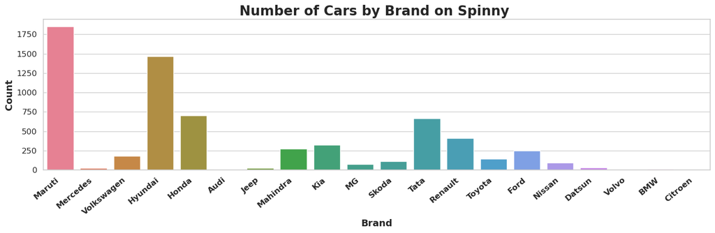

```python
plt.rcParams['font.family'] = 'DejaVu Sans'
plt.rcParams['xtick.labelsize'] = 12
plt.rcParams['ytick.labelsize'] = 12

fig = plt.figure(figsize=(15, 5))

k = sns.countplot(x='Brand', hue='Brand', data=df, palette='husl', legend=False)

# Rotate and align x-axis labels
k.set_xticklabels(k.get_xticklabels(), rotation=40, ha="right", fontweight='bold')

# Set axis labels and title with custom font
plt.xlabel("Brand", fontsize=14, fontweight='bold')
plt.ylabel("Count", fontsize=14, fontweight='bold')
plt.title("Number of Cars by Brand on Spinny ", fontsize=20, fontweight='bold')

plt.tight_layout()
plt.show()
```

#### Insights

##### Above countplot displays number of cars are available in the dataset

##### MARUTHI company have more listing in Brand wise we can see above chart

##### CITROEN Company have only 1 car

### Analysis Year and Transmission

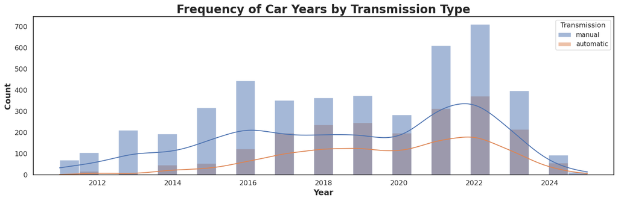

```python
sns.set(style="white")
plt.rcParams['font.family'] = 'DejaVu Sans'
plt.rcParams['xtick.labelsize'] = 12
plt.rcParams['ytick.labelsize'] = 12


plt.figure(figsize=(15, 5))
ax = sns.histplot(data=df, x="Year", hue='Transmission', kde=True, color='green')

ax.set_xlabel("Year", fontsize=14, fontweight='bold')
ax.set_ylabel("Count", fontsize=14, fontweight='bold')

ax.set_title("Frequency of Car Years by Transmission Type", fontsize=20, fontweight="bold")

plt.tight_layout()
plt.show()
```

#### Insights

##### Above Histplot is Displays a Frequency Distribution Year With Transmission

### Analysis on City

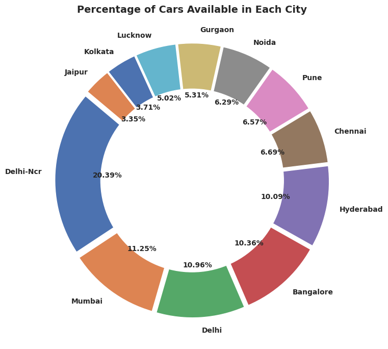

```python
city_counts = df['City'].value_counts()

explode = [0.05] * len(city_counts)

plt.figure(figsize=(10, 7))

patches, texts, autotexts = plt.pie(
    city_counts,
    labels=city_counts.index,
    autopct='%.2f%%',
    explode=explode,
    startangle=140,
    textprops={'fontsize': 10, 'weight': 'bold'}
)
centre_circle = plt.Circle((0, 0), 0.70, fc='white')
fig = plt.gcf()
fig.gca().add_artist(centre_circle)
plt.title("Percentage of Cars Available in Each City", fontsize=14, fontweight="bold")
plt.tight_layout()
plt.show()
```

#### Insights

##### The pie chart illustrates the proportion of used cars listed across various cities.

##### It helps identify which cities contribute most to the dataset.

##### Matropolian city have a more in dataset

### Analysis on Fuel Distribution

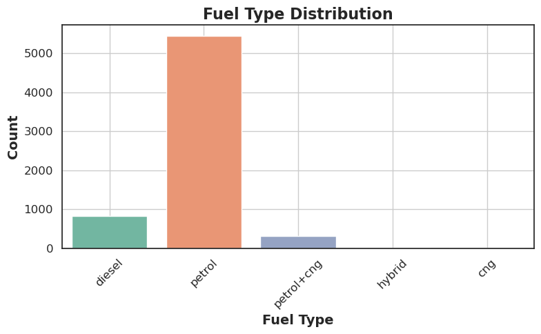

```python
plt.rcParams['font.family'] = 'DejaVu Sans'
plt.rcParams['xtick.labelsize'] = 12
plt.rcParams['ytick.labelsize'] = 12

plt.figure(figsize=(8, 5))
ax = sns.countplot(x='Fuel', data=df, palette='Set2')

ax.set_title('Fuel Type Distribution', fontsize=16, fontweight='bold')
ax.set_xlabel('Fuel Type', fontsize=14, fontweight='bold')
ax.set_ylabel('Count', fontsize=14, fontweight='bold')

plt.xticks(rotation=45)
plt.grid()

plt.tight_layout()
plt.show()
```

#### Insights

##### The countplot displays Fuel type distribution

##### Majorly the petrol cars are we have more in snippy used cars

##### Cng and hybrid are very less count

### Analysis on year

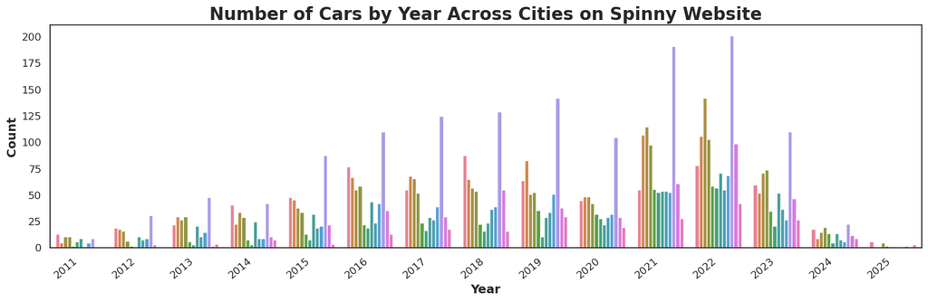

```python
plt.rcParams['font.family'] = 'DejaVu Sans'
plt.rcParams['xtick.labelsize'] = 12
plt.rcParams['ytick.labelsize'] = 12

plt.figure(figsize=(15, 5))
ax = sns.countplot(x='Year', hue='City', data=df, palette='husl', legend=False)

ax.set_xlabel("Year", fontsize=14, fontweight='bold')
ax.set_ylabel("Count", fontsize=14, fontweight='bold')
ax.set_title("Number of Cars by Year Across Cities on Spinny Website", fontsize=20, fontweight='bold')

ax.set_xticklabels(ax.get_xticklabels(), rotation=40, ha="right")

plt.tight_layout()
plt.show()
```

### Insights

##### The distribution of car manufacturing years helps us understand the age profile of used cars in the market.

##### Above countplot displays Year of manufacturing

##### 2021 and 2022 year of cars have more used cars to sell

# Bivariate Analysis

### Analysis on Year and Fuel

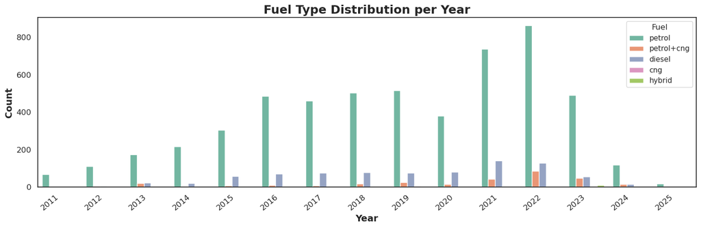

```python
plt.rcParams['font.family'] = 'DejaVu Sans'
plt.rcParams['xtick.labelsize'] = 12
plt.rcParams['ytick.labelsize'] = 12

plt.figure(figsize=(15, 5))
ax = sns.countplot(x='Year', data=df, hue='Fuel', palette='Set2')

ax.set_title("Fuel Type Distribution per Year", fontsize=18, fontweight='bold')
ax.set_xlabel("Year", fontsize=14, fontweight='bold')
ax.set_ylabel("Count", fontsize=14, fontweight='bold')

ax.set_xticklabels(ax.get_xticklabels(), rotation=40, ha="right")
plt.tight_layout()
plt.show()
```

### Insights

##### Analyzing how fuel type distribution changes across years.

##### Above countplot petrol is dominating in dataset.

##### Cng and hybrid are less used cars

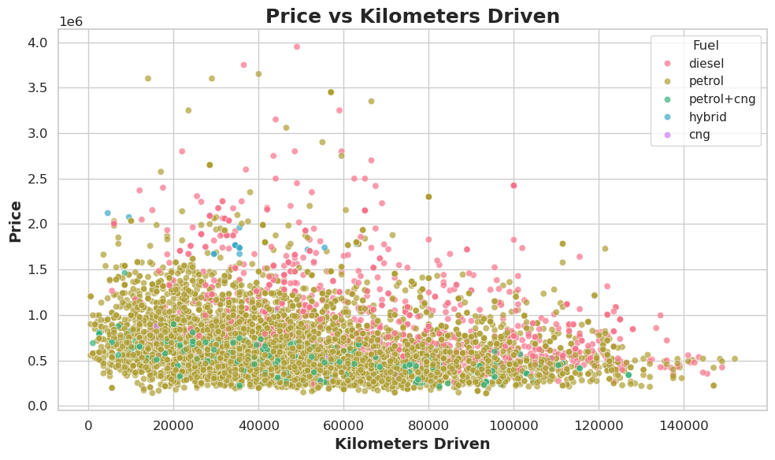

```python
sns.set(style="whitegrid")
plt.rcParams['font.family'] = 'DejaVu Sans'
plt.rcParams['xtick.labelsize'] = 12
plt.rcParams['ytick.labelsize'] = 12

plt.figure(figsize=(10, 6))
sns.scatterplot(x='KMS', y='Price', data=df, hue='Fuel', palette='husl', alpha=0.7)

plt.title("Price vs Kilometers Driven", fontsize=18, fontweight='bold')
plt.xlabel("Kilometers Driven", fontsize=14, fontweight='bold')
plt.ylabel("Price", fontsize=14, fontweight='bold')

plt.tight_layout()
plt.show()
```

#### Above scater plot displays a distrubtion

#### Price decreases as KMS increases

### analysis on Price and KMS

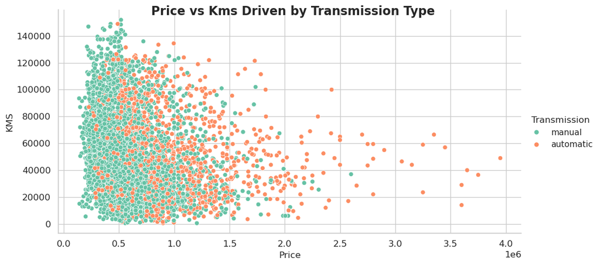

```python
sns.set(style="whitegrid")
plt.rcParams['font.family'] = 'DejaVu Sans'
plt.rcParams['xtick.labelsize'] = 12
plt.rcParams['ytick.labelsize'] = 12

g = sns.relplot(
    x="Price", y="KMS", hue="Transmission",
    data=df, kind='scatter', height=5, aspect=2, palette='Set2'
)

g.fig.suptitle("Price vs Kms Driven by Transmission Type",
               fontsize=16, fontweight='bold')
```

### Analysis on Brand and KMS with TRans

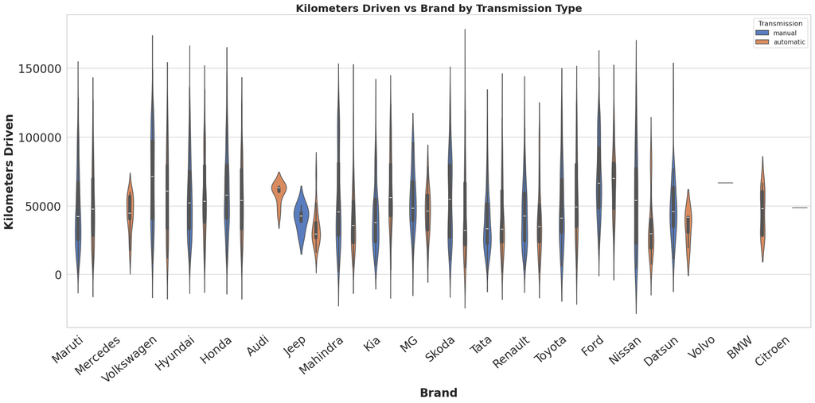

```python
plt.rcParams['font.family'] = 'DejaVu Sans'
plt.rcParams['xtick.labelsize'] = 20
plt.rcParams['ytick.labelsize'] = 20

# Create the plot
plt.figure(figsize=(20, 10))
ax = sns.violinplot(x="Brand", y="KMS", hue="Transmission",
                    data=df, palette="muted")

\
ax.set_title("Kilometers Driven vs Brand by Transmission Type", fontsize=18, fontweight="bold")
ax.set_xlabel("Brand", fontsize=20, fontweight="bold")
ax.set_ylabel("Kilometers Driven", fontsize=20, fontweight="bold")

ax.set_xticklabels(ax.get_xticklabels(), rotation=40, ha="right")

plt.tight_layout()
plt.show()
```

#### Insights

##### This violin plot compares the distribution of kilometers driven for different car brands, split by gear transmission type.

##### Most of used cars are manual transmission

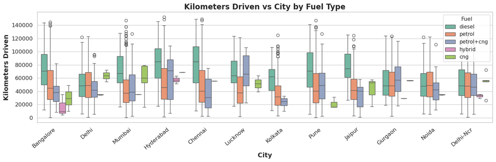

```python
plt.rcParams['font.family'] = 'DejaVu Sans'
plt.rcParams['xtick.labelsize'] = 12
plt.rcParams['ytick.labelsize'] = 12

plt.figure(figsize=(15, 5))
ax = sns.boxplot(x='City', y='KMS', hue='Fuel', data=df, palette='Set2')

ax.set_title("Kilometers Driven vs City by Fuel Type", fontsize=16, fontweight="bold")
ax.set_xlabel("City", fontsize=14, fontweight="bold")
ax.set_ylabel("Kilometers Driven", fontsize=14, fontweight="bold")
ax.set_xticklabels(ax.get_xticklabels(), rotation=40, ha="right")

plt.tight_layout()
plt.show()
```

## Groupby aggregation operation

#### Top 10 cars highest price

```python
top_10car = df.groupby("Brand")['Price'].max().nlargest(10)
top10 = pd.DataFrame(top_10car)
```

```python
top10_car = pd.merge(top10,df,on = "Price")
top10_car
```

|  | Price | Brand | Car | Year | City | KMS | Fuel | Transmission | Emi |
| --- | --- | --- | --- | --- | --- | --- | --- | --- | --- |
| 0 | 3950000.0 | Mercedes | E-ClassE220d Expression | 2021 | Hyderabad | 49000.0 | diesel | automatic | 67936 |
| 1 | 3350000.0 | Volvo | XC40B4 Ultimate | 2022 | Bangalore | 66500.0 | petrol | automatic | 57616 |
| 2 | 3250000.0 | MG | GlosterSavvy 2.0 Twin Turbo 6 STR 4WD | 2021 | Bangalore | 59000.0 | diesel | automatic | 55896 |
| 3 | 3250000.0 | Mercedes | C-ClassC 200 Progressive | 2021 | Hyderabad | 23500.0 | petrol | automatic | 55896 |
| 4 | 3059000.0 | Toyota | Fortuner4X2 AT 2.7 Petrol | 2022 | Bangalore | 46500.0 | petrol | automatic | 52610 |
| 5 | 2800000.0 | Jeep | MeridianLimited (O) 4X2 AT | 2022 | Mumbai | 22000.0 | diesel | automatic | 48156 |
| 6 | 2800000.0 | Mercedes | C-ClassC 220 CDI Progressive | 2019 | Mumbai | 48500.0 | diesel | automatic | 48156 |
| 7 | 2800000.0 | Mercedes | GLC220d Progressive | 2017 | Chennai | 59500.0 | diesel | automatic | 48156 |
| 8 | 2750000.0 | Audi | A635 TDI S LINE Matrix | 2019 | Bangalore | 43500.0 | diesel | automatic | 47296 |
| 9 | 2750000.0 | BMW | X3xDrive 30i Luxury Line | 2018 | Chennai | 59500.0 | petrol | automatic | 47296 |
| 10 | 2750000.0 | Audi | A635 TDI S LINE Matrix | 2019 | Bangalore | 43500.0 | diesel | automatic | 47296 |
| 11 | 2750000.0 | BMW | X3xDrive 30i Luxury Line | 2018 | Chennai | 59500.0 | petrol | automatic | 47296 |
| 12 | 2600000.0 | Ford | EndeavourTitanium 2.2 4x2 MT | 2019 | Bangalore | 37000.0 | diesel | manual | 44716 |
| 13 | 2575000.0 | Mahindra | XUV700AX7 Luxury Pack Petrol AT 7 STR | 2024 | Bangalore | 17000.0 | petrol | automatic | 44287 |
| 14 | 2424000.0 | Kia | CarnivalLimousine | 2022 | Delhi | 100000.0 | diesel | automatic | 41687 |
| 15 | 2424000.0 | Kia | CarnivalLimousine | 2022 | Jaipur | 100000.0 | diesel | automatic | 41687 |
| 16 | 2424000.0 | Kia | CarnivalLimousine | 2022 | Gurgaon | 100000.0 | diesel | automatic | 41687 |
| 17 | 2424000.0 | Kia | CarnivalLimousine | 2022 | Noida | 100000.0 | diesel | automatic | 41687 |
| 18 | 2424000.0 | Kia | CarnivalLimousine | 2022 | Delhi-Ncr | 100000.0 | diesel | automatic | 41687 |

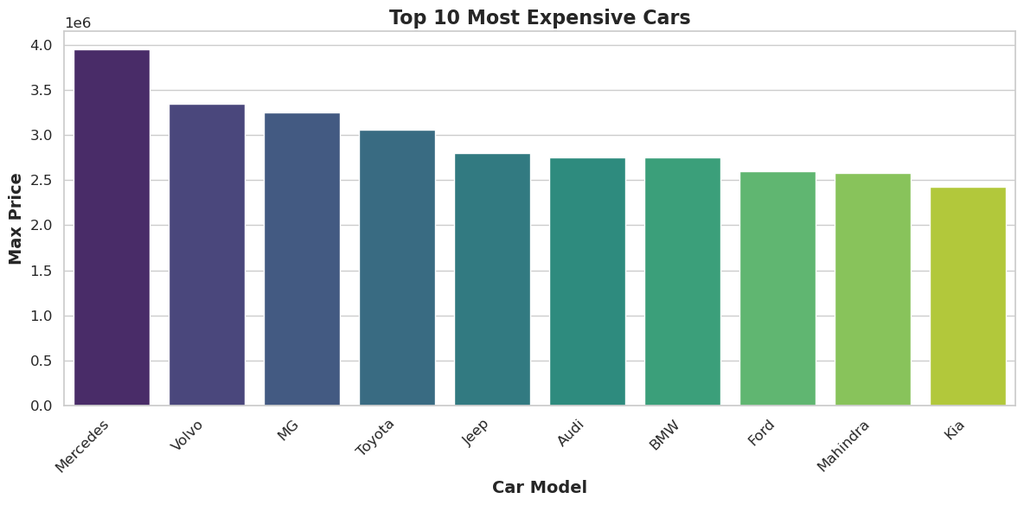

```python
plt.rcParams['font.family'] = 'DejaVu Sans'
plt.rcParams['xtick.labelsize'] = 12
plt.rcParams['ytick.labelsize'] = 12

plt.figure(figsize=(12, 6))
ax = sns.barplot(x=top10.index, y='Price', data=top10, palette='viridis')

ax.set_title('Top 10 Most Expensive Cars', fontsize=16, fontweight='bold')
ax.set_xlabel('Car Model', fontsize=14, fontweight='bold')
ax.set_ylabel('Max Price', fontsize=14, fontweight='bold')

plt.xticks(rotation=45, ha='right')

plt.tight_layout()
plt.show()
```

### Here we can find high price cars in which city

```python
Top=df.groupby(["City"])[["Price","KMS","Brand","Car","Transmission","Fuel"]].max()
Top=pd.DataFrame(Top)
Top=Top.reset_index()
Top
```

|  | City | Price | KMS | Brand | Car | Transmission | Fuel |
| --- | --- | --- | --- | --- | --- | --- | --- |
| 0 | Bangalore | 3750000.0 | 144500.0 | Volvo | i20Sportz 1.4 CRDI | manual | petrol+cng |
| 1 | Chennai | 2800000.0 | 149000.0 | Volkswagen | i20 N LineN8 1.0 Turbo DCT Dual Tone | manual | petrol+cng |
| 2 | Delhi | 3450000.0 | 123000.0 | Volkswagen | i20Sportz 1.2 | manual | petrol+cng |
| 3 | Delhi-Ncr | 3450000.0 | 124000.0 | Volkswagen | i20Sportz 1.2 | manual | petrol+cng |
| 4 | Gurgaon | 3450000.0 | 124000.0 | Volkswagen | i20 Active1.2 SX | manual | petrol+cng |
| 5 | Hyderabad | 3950000.0 | 152000.0 | Volkswagen | i20Sportz (O) 1.2 MT | manual | petrol+cng |
| 6 | Jaipur | 3450000.0 | 125500.0 | Volkswagen | i20Sportz 1.2 | manual | petrol+cng |
| 7 | Kolkata | 1952000.0 | 125000.0 | Volkswagen | i20 N LineN8 1.0 Turbo DCT | manual | petrol+cng |
| 8 | Lucknow | 2005000.0 | 123500.0 | Volkswagen | i20Asta (O) 1.2 IVT | manual | petrol+cng |
| 9 | Mumbai | 3600000.0 | 147000.0 | Volkswagen | i20Magna 1.2 | manual | petrol+cng |
| 10 | Noida | 3450000.0 | 122500.0 | Volkswagen | i20Asta 1.2 | manual | petrol+cng |
| 11 | Pune | 3600000.0 | 147000.0 | Volkswagen | i20Magna 1.2 | manual | petrol+cng |

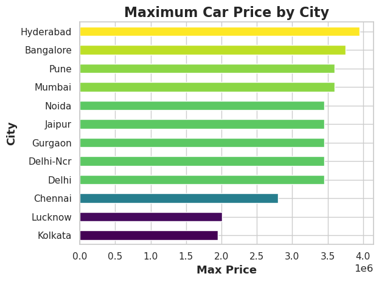

```python
Top_sorted = Top.sort_values('Price')
norm = mcolors.Normalize(vmin=Top_sorted['Price'].min(), vmax=Top_sorted['Price'].max())
colors = cm.viridis(norm(Top_sorted['Price']))
plt.figure(figsize=(12, 6))
ax = Top_sorted.plot(kind='barh', x='City', y='Price', color=colors, legend=False)

ax.set_title("Maximum Car Price by City", fontsize=16, fontweight="bold")
ax.set_xlabel("Max Price", fontsize=13, fontweight="bold")
ax.set_ylabel("City", fontsize=13, fontweight="bold")


plt.xticks(fontsize=11)
plt.yticks(fontsize=11)

plt.tight_layout()
plt.show()
```

#### Here we find low price cars in which city

```python
low=df.groupby(["City"])[["Price","KMS","Brand","Car","Transmission","Fuel"]].min()
low=pd.DataFrame(low)
low=low.reset_index()
low
```

|  | City | Price | KMS | Brand | Car | Transmission | Fuel |
| --- | --- | --- | --- | --- | --- | --- | --- |
| 0 | Bangalore | 149000.0 | 500.0 | Audi | A-StarVxi | automatic | cng |
| 1 | Chennai | 229000.0 | 2500.0 | BMW | 5 Series520d Luxury Line | automatic | diesel |
| 2 | Delhi | 140000.0 | 1000.0 | Audi | A335 TFSI Premium Plus | automatic | cng |
| 3 | Delhi-Ncr | 140000.0 | 1000.0 | Audi | A-StarVXI | automatic | cng |
| 4 | Gurgaon | 187000.0 | 2500.0 | Audi | A-StarVXI | automatic | cng |
| 5 | Hyderabad | 170000.0 | 1500.0 | BMW | A-StarVXI | automatic | cng |
| 6 | Jaipur | 231000.0 | 1000.0 | Audi | A335 TFSI Premium Plus | automatic | cng |
| 7 | Kolkata | 151000.0 | 3000.0 | Datsun | A-StarVxi | automatic | diesel |
| 8 | Lucknow | 178000.0 | 2000.0 | Datsun | A-StarVxi | automatic | cng |
| 9 | Mumbai | 149000.0 | 500.0 | Audi | 3 Series GT320d GT Sport Line | automatic | cng |
| 10 | Noida | 166000.0 | 5500.0 | Audi | A-StarVXI AT | automatic | diesel |
| 11 | Pune | 143000.0 | 500.0 | BMW | 3 Series GT320d GT Sport Line | automatic | cng |

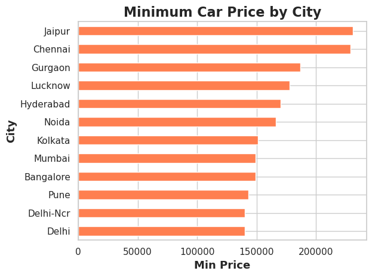

```python
low_sorted = low.sort_values('Price')

plt.figure(figsize=(12, 6))
ax = low_sorted.plot(kind='barh', x='City', y='Price', color='coral', legend=False)

ax.set_title("Minimum Car Price by City", fontsize=16, fontweight="bold")
ax.set_xlabel("Min Price", fontsize=13, fontweight="bold")
ax.set_ylabel("City", fontsize=13, fontweight="bold")
plt.xticks(fontsize=11)
plt.yticks(fontsize=11)

plt.tight_layout()
plt.show()
```

### Continuous to Continuous Variable: Correlation Plot

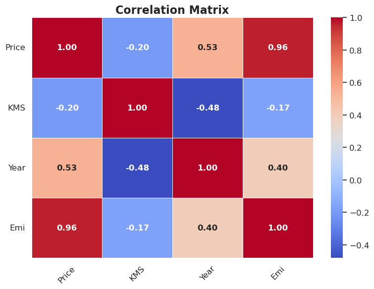

```python
col = ['Price', 'KMS', 'Year', 'Emi']
corr_matrix = df[col].corr()

plt.figure(figsize=(8, 6))
ax = sns.heatmap(corr_matrix, annot=True, cmap='coolwarm', fmt='.2f', linewidths=0.5,
                 annot_kws={"size": 12, "weight": "bold"})

plt.title('Correlation Matrix', fontsize=16, fontweight='bold')
plt.xticks(fontsize=12, rotation=45)
plt.yticks(fontsize=12, rotation=0)
plt.tight_layout()
plt.show()
```

#### Insights

Price & EMI: Strong positive correlation (0.96) – higher price means higher EMI.

Price & Year: Moderate positive (0.53) – newer cars cost more.

Price & KMS: Weak negative (-0.20) – more driven cars are slightly cheaper.

Year & KMS: Moderate negative (-0.48) – newer cars have fewer kilometers.

Year & EMI: Moderate positive (0.40) – newer cars tend to have higher EMI.

#### Crosstab between Fuel and Transmission

```python
ct = pd.crosstab(df['Fuel'], df['Transmission'])
ct_percent = pd.crosstab(df['Fuel'], df['Transmission'], normalize='index') * 100

print(ct)
print(ct_percent.round(2))
```

```
Transmission  automatic  manual
Fuel
cng                   0      25
diesel              266     571
hybrid               15       0
petrol             1819    3636
petrol+cng            1     317
Transmission  automatic  manual
Fuel
cng                0.00  100.00
diesel            31.78   68.22
hybrid           100.00    0.00
petrol            33.35   66.65
petrol+cng         0.31   99.69
```

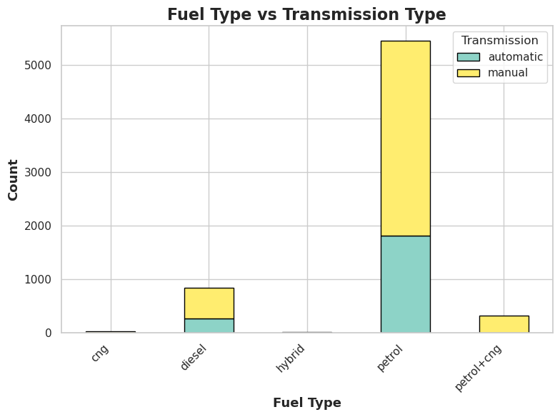

```python
ct.plot(kind='bar', stacked=True, colormap='Set3', figsize=(8, 6), edgecolor='black')


plt.title('Fuel Type vs Transmission Type', fontsize=16, fontweight='bold')
plt.xlabel('Fuel Type', fontsize=13, fontweight='bold')
plt.ylabel('Count', fontsize=13, fontweight='bold')

plt.legend(title='Transmission', fontsize=11, title_fontsize=12)

plt.xticks(fontsize=11, rotation=45, ha='right')
plt.yticks(fontsize=11)

plt.tight_layout()
plt.show()
```

To examine the frequency distribution or relationship between two categorical variables.

# Used Cars Data Analysis Project – Summary

### Objective:

##### To perform exploratory data analysis (EDA) on a used cars dataset to uncover insights into pricing trends, brand preferences, and key factors affecting resale value.